# EDA on Prosper Loan Data by Dalal Alwedaah

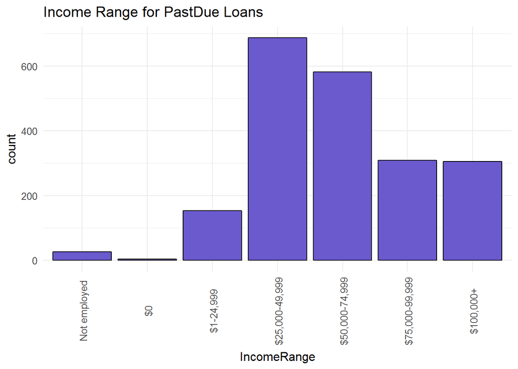

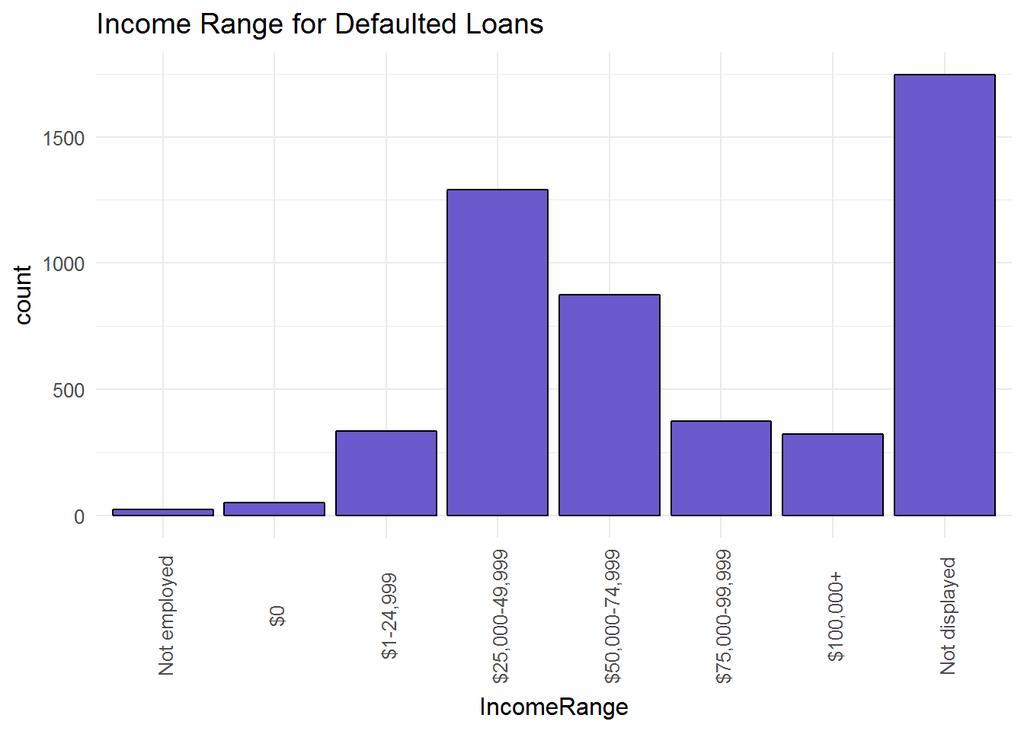

Here we can see that completed loans are left skewed into highest rating( 10 is the best, or lowest risk score) and the charged off loans normally distributed.

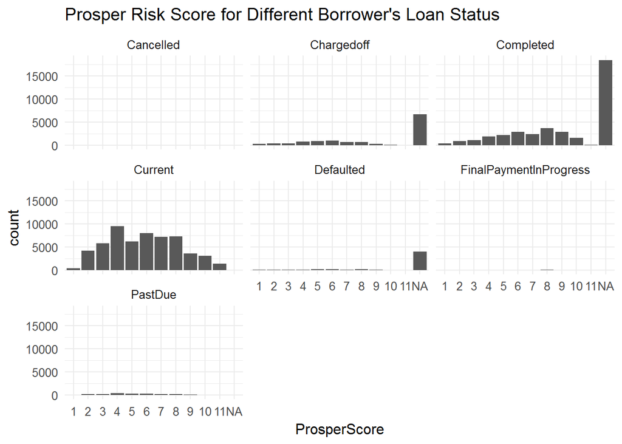

The pastdue loans is same as current loans there are no special thing about it.

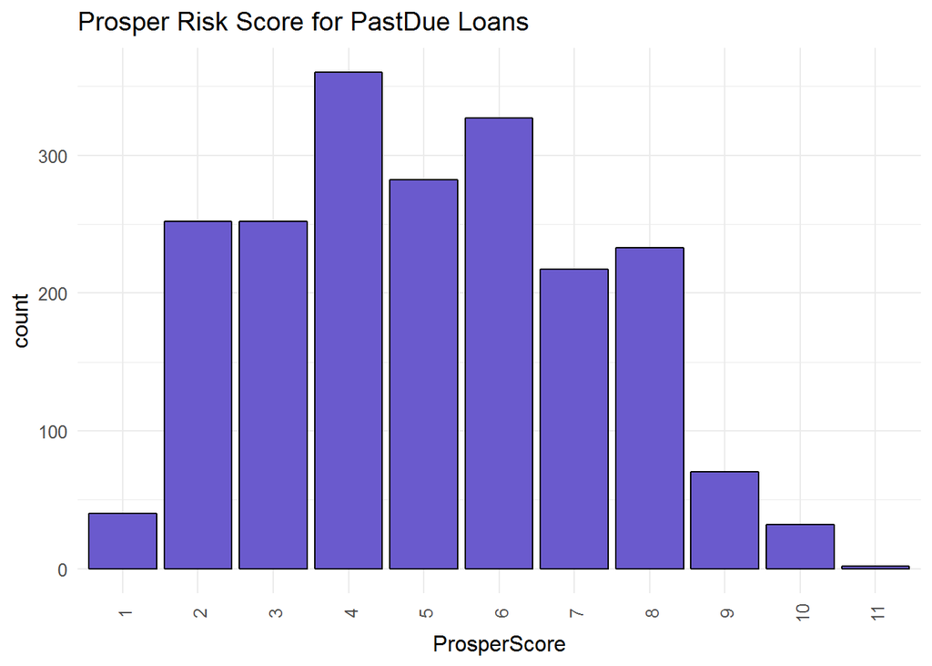

The defaulted loans are widely spread along all scores which is unexpected for me.

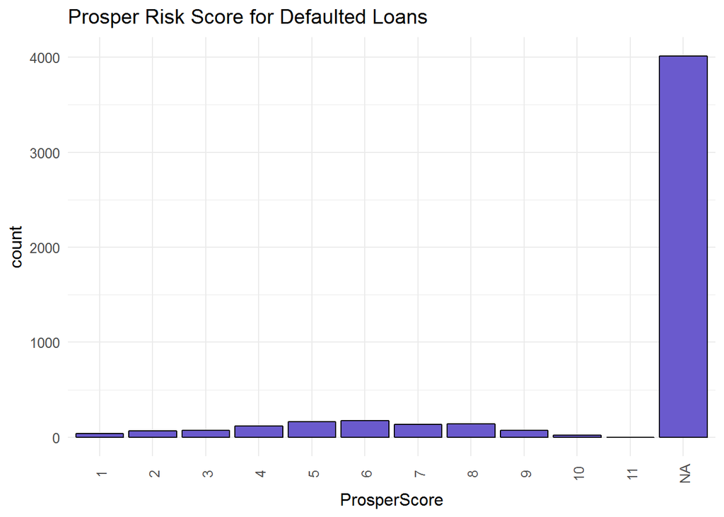

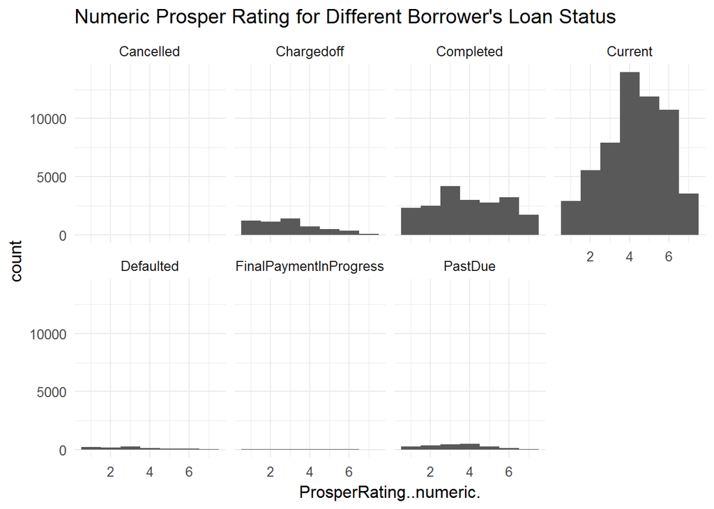

The prosper rating for Defaulted loans are rightly skewed which means The borrowers with highest rating (better) have more probability to pay their loans.

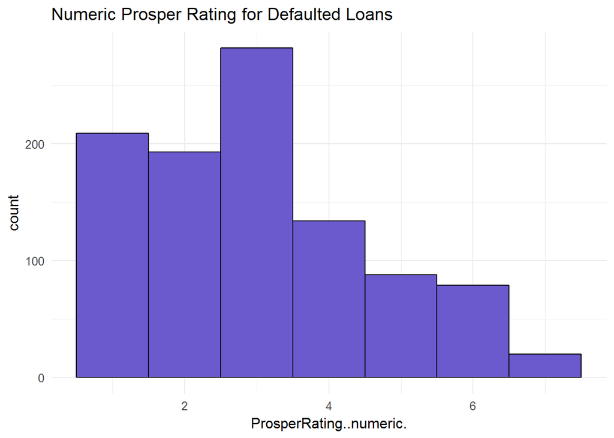

We can see that the current loans are like normal distribution. When the rating being worst the number of loan increased in chargeed off loans. the compleated loan like bi-model destribution. there are tow peaks in D and A rating.

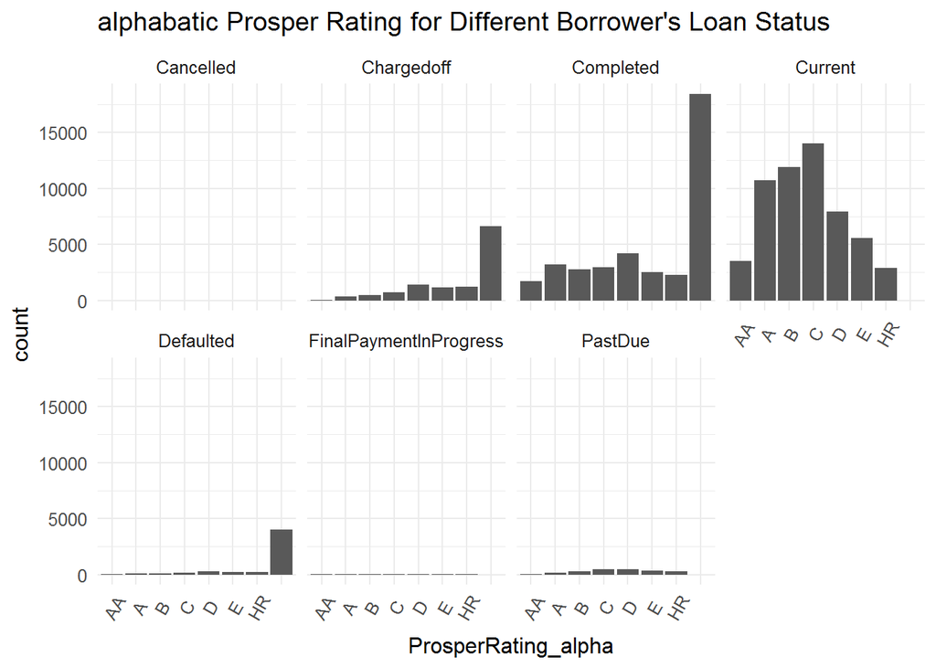

We can see here When the rating being worst the number of Defaulted loan are increased.

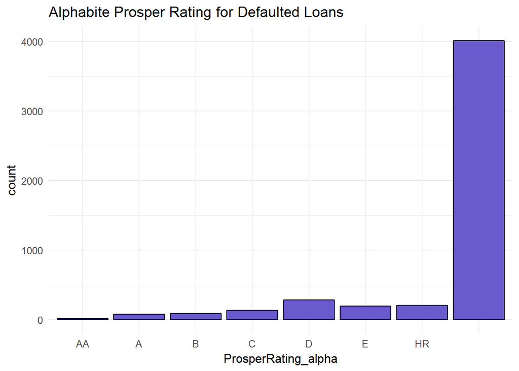

I want to see the relation between numeric Prosper Rating and risk score. The plot below show they are correlated.

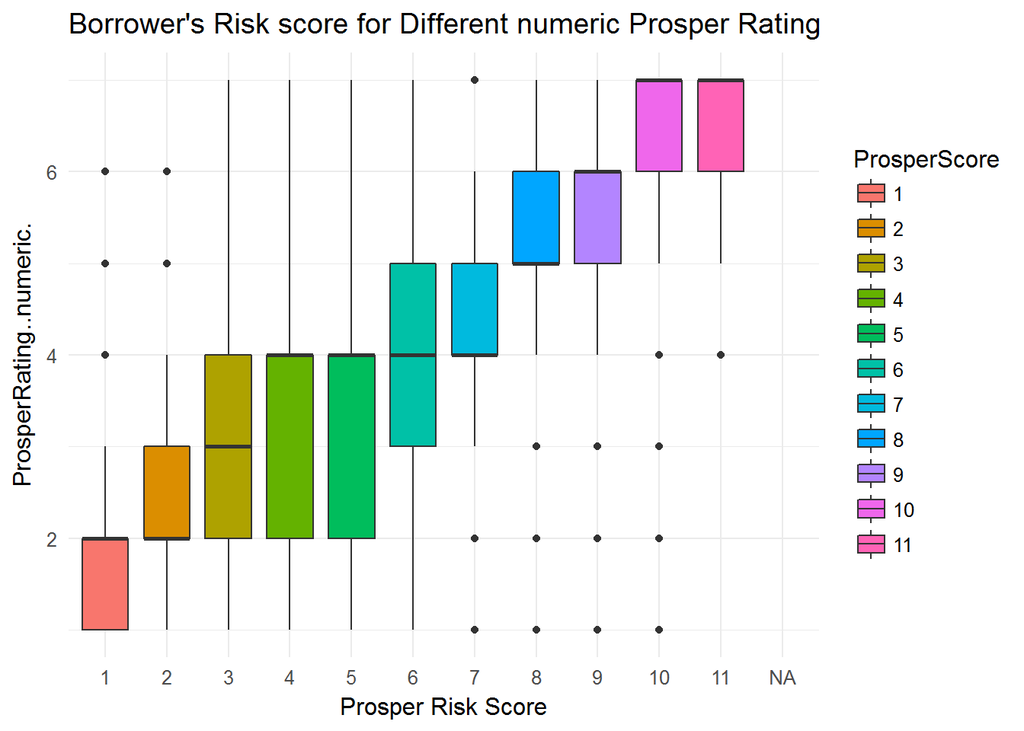

What the relation between owning homes and Loan Status? no relation!

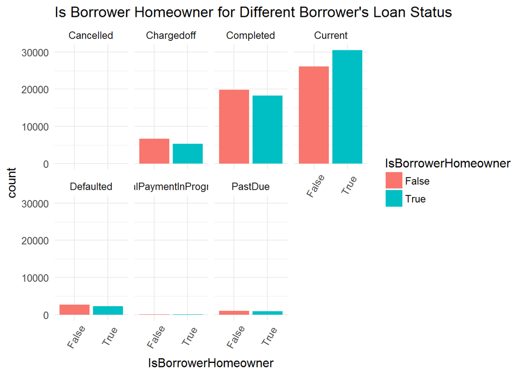

What the relation between owning homes and Prosper Rating? owning home is good indicator for the score.

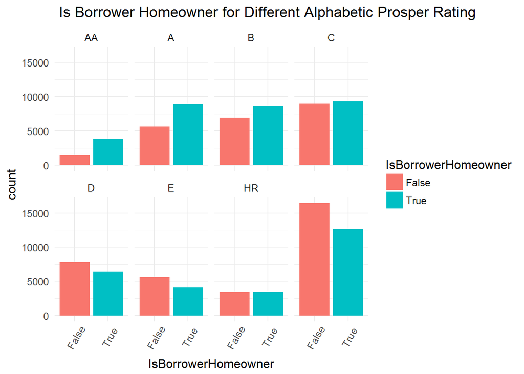

How lender yield varies based on borrower state?

[interactive chart not shown]

We can see there are top state that give you max yield is Alabama. Other states like: Nevada, Idaho, North Dakota, South Dakota, Missouri ,Arkansas, Mississippi, Tennessee, Kentucky give you yield between 0.19 and 0.202

The next plot show that lender yield is better a bit when the borrower is not a Homeowner. there are outlier with yield above 0.4 for whom don’t own a home.

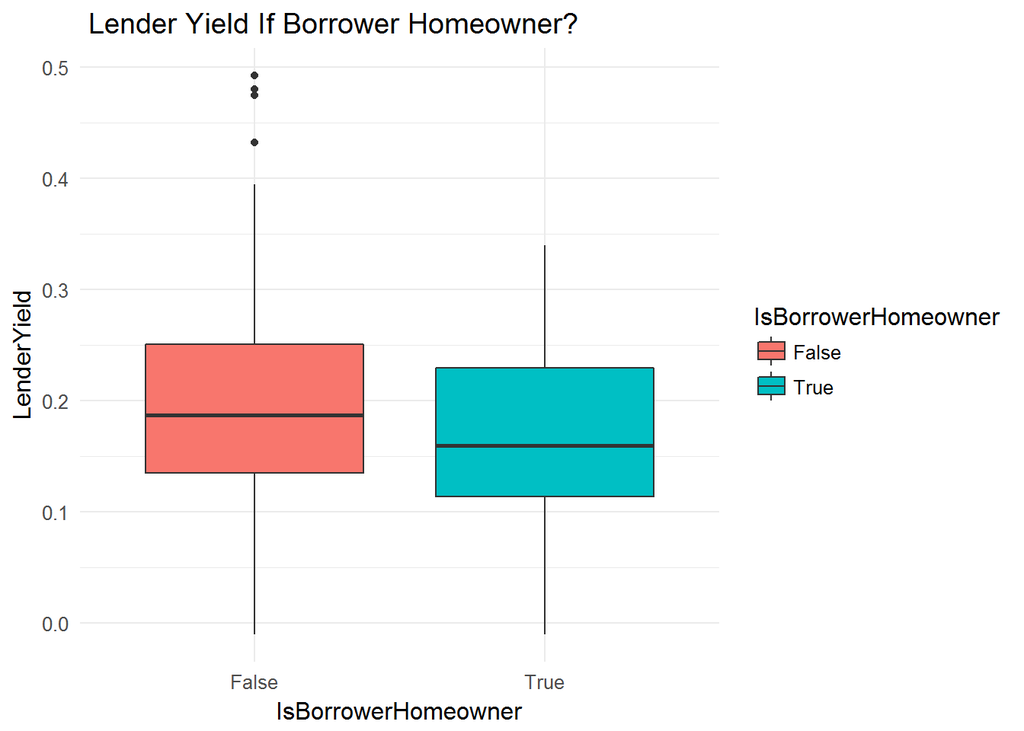

Here we can not see any strong relationship between lender yield and loan purpose

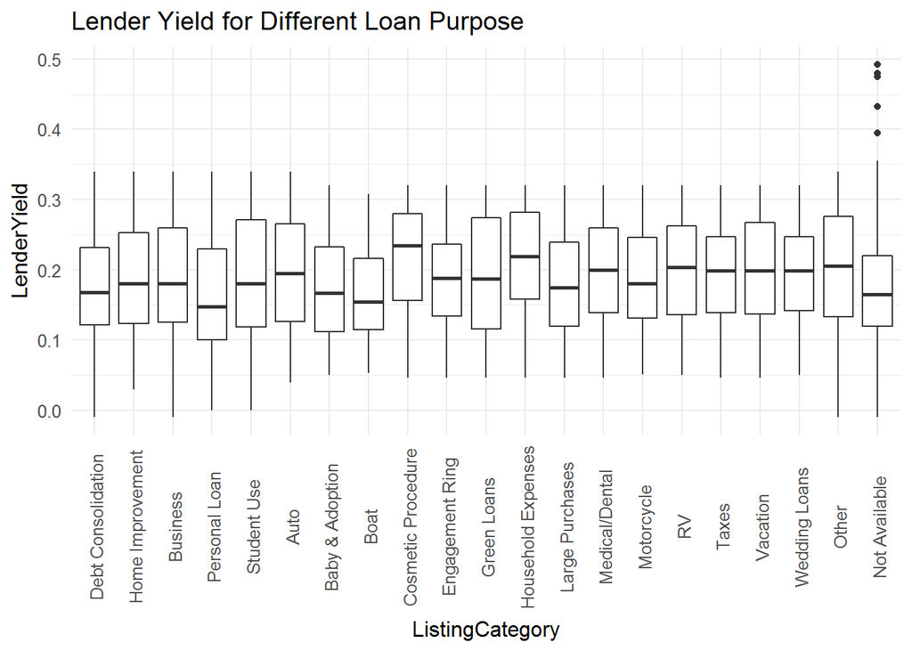

We want to see the relation between lender yield and term.

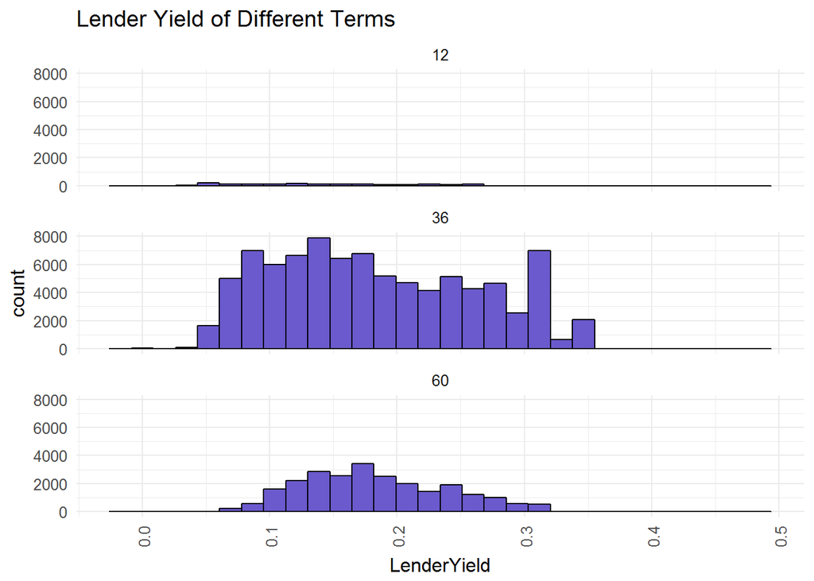

We can see that 36 term is the term that give lenders maximum yield. 12 term give the minimum one.

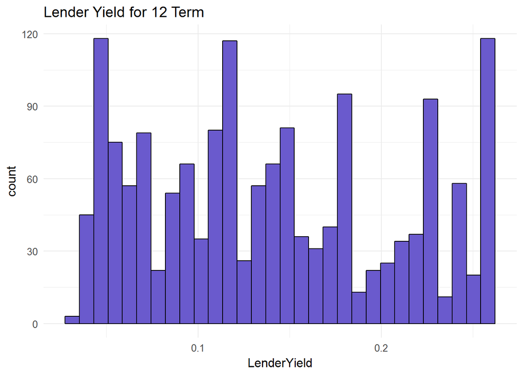

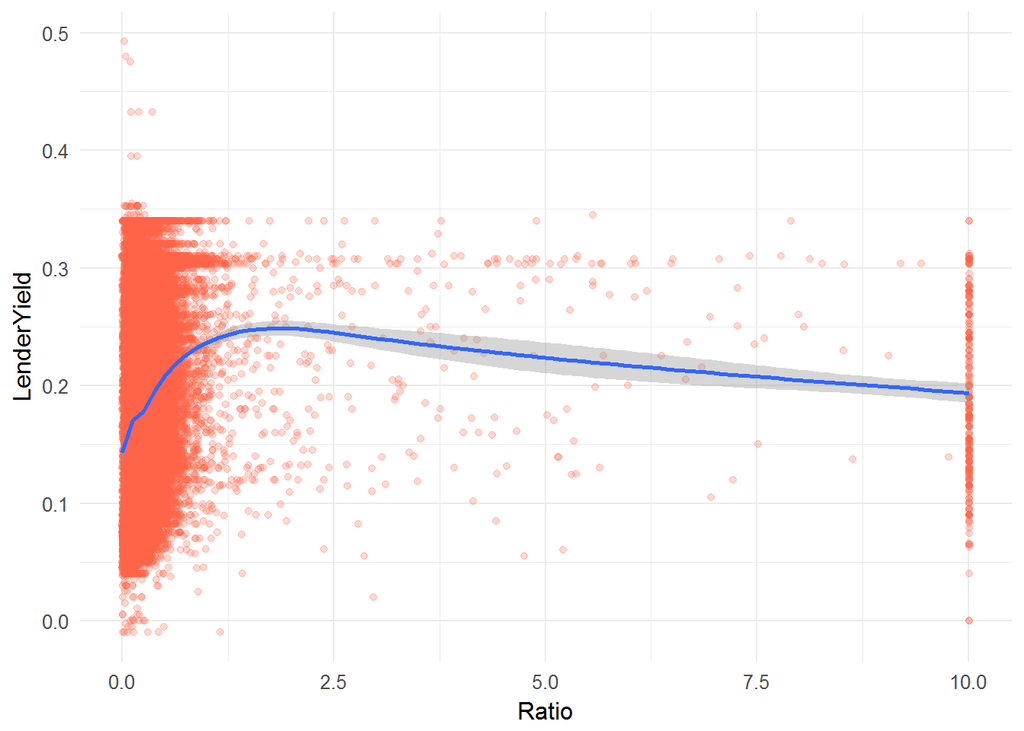

```
## $title
## [1] "Lender Yield of Debt To Income Ratio"
##
## $subtitle
## NULL
##
## attr(,"class")
## [1] "labels"
```

we can not see strong relation between lender yield and debt to income ratio. When we calculate correlation, it is very low 0.06.

```
## [1] 0.06194247
```

We can see there are negative relation between lender yield and risk score.When risk rating decreased, the yield increased.when you lending , you should choose 5 risk score which give us lower risk with high yield.

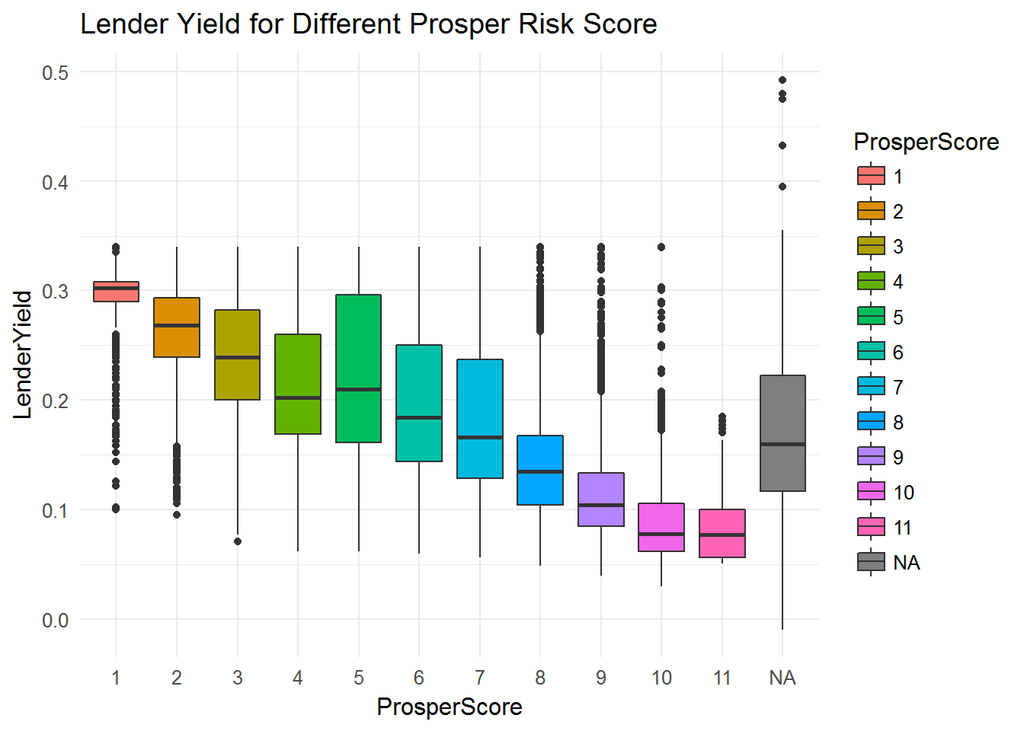

Also we can see here that Prosper Rating is correlated with lender yield. the high rating means low yield and the opposite is true.

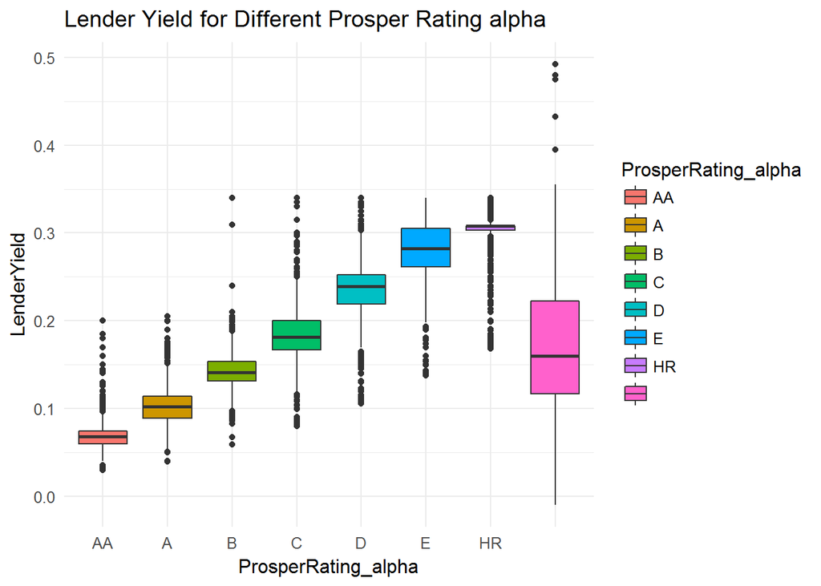

Here we can see the relation between lender yield and numeric score which is the same as alphabetic score. The correlation between lender yield and numeric score is very high we get -0.953 correlation score.

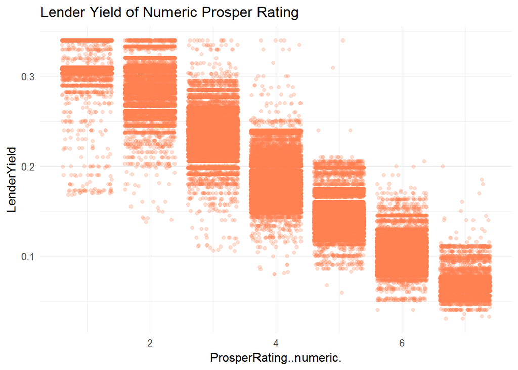

```
## [1] -0.9531194
```

# Bivariate Analysis

### Did you observe any interesting relationships between the other features (not the main feature(s) of interest)?

Yes, there are some relation between owning home and Alphabetic Prosper Rating. The percentage of owning home in high rating is more than low rating.

### What was the strongest relationship you found?

The strongest relationship I found is between lender yield and numeric prosper score which equal -0.953 correlation score.

# Multivariate Plots Section

First, I want to see the effect of owning home on Lender Yield and Prosper Risk Score. Owning home doesn’t affect on lenderyieled the two graphs are almost the same.

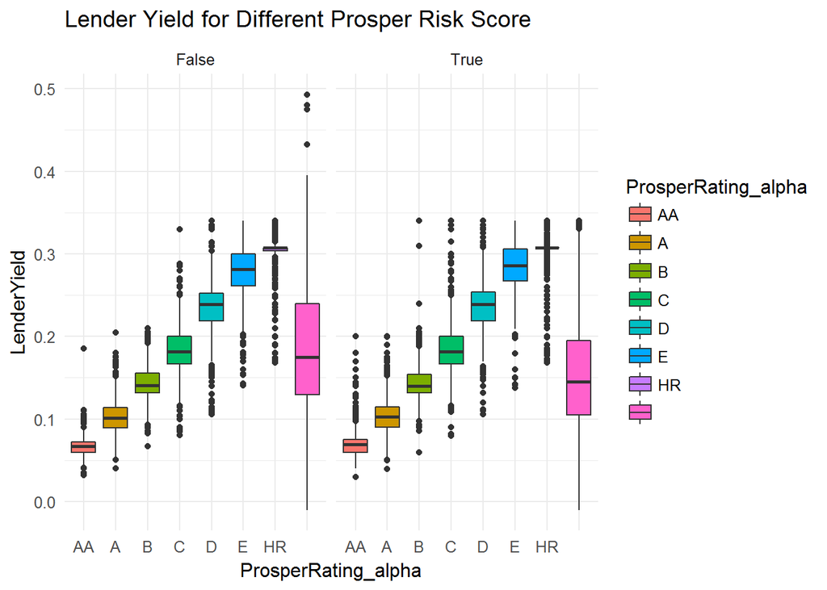

Then, I want to explore Lender Yield over Debt To Income Ratio and Term. I use the lender yield mean (0.1827)to categorize it.

```
##    Min. 1st Qu.  Median    Mean 3rd Qu.    Max.
## -0.0100  0.1242  0.1730  0.1827  0.2400  0.4925
```

There are many intersting things in this plot. 36 term loans are covered all  
DebtToIncomeRatio axes(0 to 10) when most of 12 and 60 term loans are under 1.5 ratio. Most lender yield of 12 term bellow the average and 60 term above it.

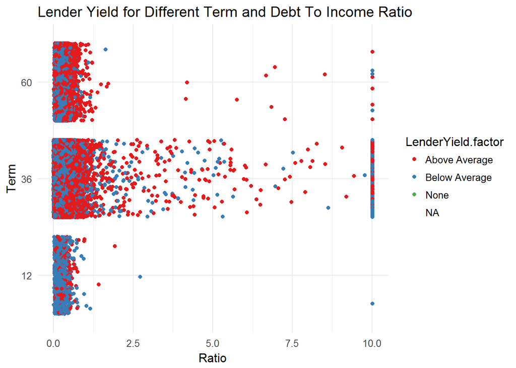

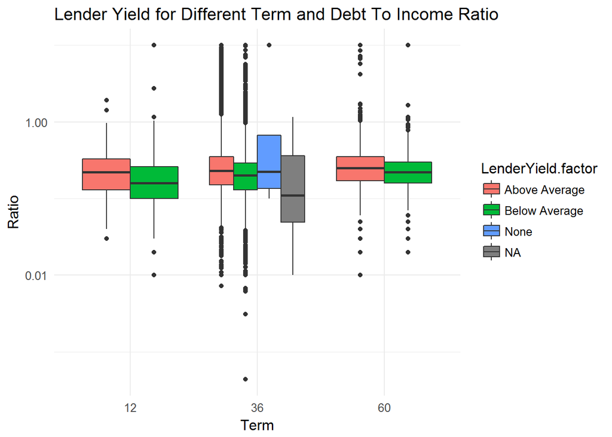

Here, I am curious about LenderYield with Term and ProsperRating_alpha. As what we see before, These two variable are correlated with LenderYield. the correlation is being more clear. the E and HR scores for 36 term and E score for 60 term are tend to high return.

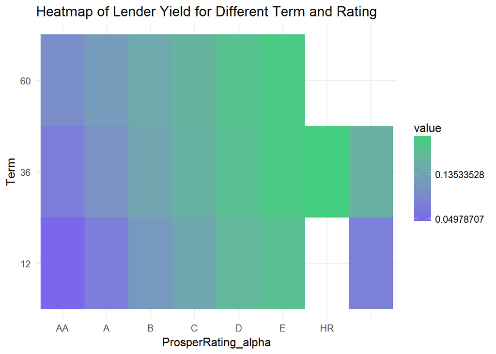

In the next plot we can see there are no relation between lender yield and Debt to Income Ratio. the correlation score is 0.06 which is very low. we can see the strong relation between lender yield and prosper score. the ratio is increased in Exponential way when the risk score is decreased.

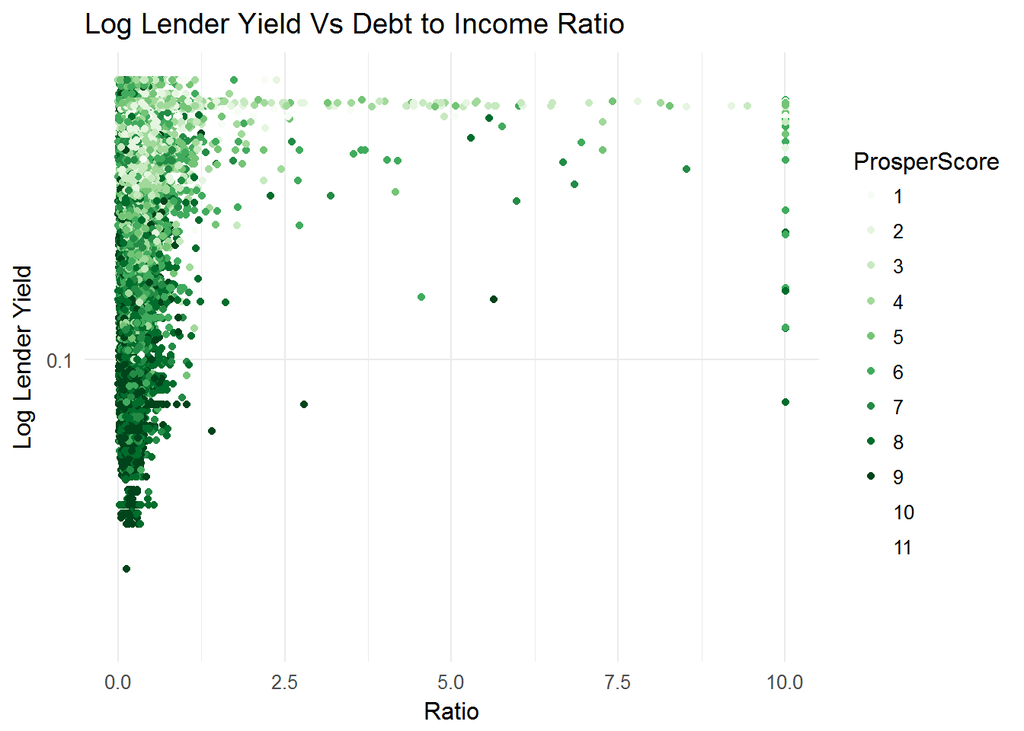

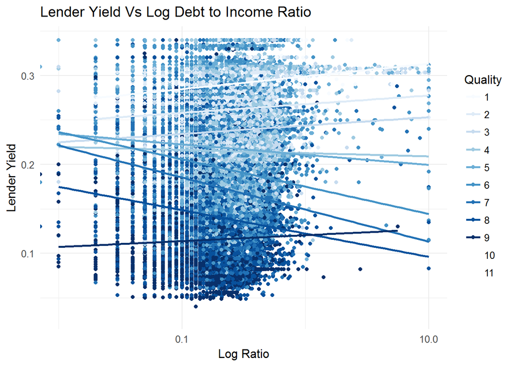

```
## [1] 0.06194247
```

Finally, we build linear model for predicting lender yield.

```
##
## Calls:
## m1: lm(formula = LenderYield ~ DebtToIncomeRatio, data = loandata)
## m2: lm(formula = LenderYield ~ DebtToIncomeRatio + Term, data = loandata)
## m3: lm(formula = LenderYield ~ DebtToIncomeRatio + Term + ProsperScore,
##     data = loandata)
## m4: lm(formula = LenderYield ~ DebtToIncomeRatio + Term + ProsperScore +
##     ProsperRating..numeric., data = loandata)
## m5: lm(formula = LenderYield ~ DebtToIncomeRatio + Term + ProsperScore +
##     ProsperRating..numeric. + BorrowerState, data = loandata)
##
## ============================================================================================
##                                m1           m2           m3           m4           m5
## --------------------------------------------------------------------------------------------
##   (Intercept)                0.178***     0.132***     0.256***     0.335***     0.335***
##                             (0.000)      (0.002)      (0.003)      (0.001)      (0.002)
##   DebtToIncomeRatio          0.008***     0.008***     0.007***    -0.000       -0.000
##                             (0.000)      (0.000)      (0.001)      (0.000)      (0.000)
##   Term: 36/12                             0.047***     0.034***     0.034***     0.034***
##                                          (0.002)      (0.001)      (0.001)      (0.001)
##   Term: 60/12                             0.047***     0.033***     0.043***     0.043***
##                                          (0.002)      (0.002)      (0.001)      (0.001)
##   ProsperScore: 2                                     -0.030***    -0.012***    -0.012***
##                                                       (0.002)      (0.001)      (0.001)
##   ProsperScore: 3                                     -0.054***    -0.013***    -0.013***
##                                                       (0.002)      (0.001)      (0.001)
##   ProsperScore: 4                                     -0.077***    -0.014***    -0.014***
##                                                       (0.002)      (0.001)      (0.001)
##   ProsperScore: 5                                     -0.073***    -0.006***    -0.006***
##                                                       (0.002)      (0.001)      (0.001)
##   ProsperScore: 6                                     -0.096***    -0.003**     -0.003***
##                                                       (0.002)      (0.001)      (0.001)
##   ProsperScore: 7                                     -0.117***    -0.002*      -0.002*
##                                                       (0.002)      (0.001)      (0.001)
##   ProsperScore: 8                                     -0.149***    -0.002*      -0.002**
##                                                       (0.002)      (0.001)      (0.001)
##   ProsperScore: 9                                     -0.176***    -0.004***    -0.005***
##                                                       (0.002)      (0.001)      (0.001)
##   ProsperScore: 10                                    -0.202***    -0.003***    -0.003***
##                                                       (0.002)      (0.001)      (0.001)
```

[output cut: 95 more lines]

```
##                                                                                 (0.002)
##   BorrowerState: WY/AK                                                          -0.000
##                                                                                 (0.003)
## --------------------------------------------------------------------------------------------
##   R-squared                      0.004        0.009        0.452        0.920        0.920
##   adj. R-squared                 0.004        0.009        0.452        0.920        0.920
##   sigma                          0.074        0.073        0.055        0.021        0.021
##   F                            405.891      325.791     4925.210    63358.545    14552.771
##   p                              0.000        0.000        0.000        0.000        0.000
##   Log-likelihood            125377.281   125661.174   115334.955   189746.520   189796.253
##   Deviance                     571.360      568.290      231.990       34.049       34.006
##   AIC                      -250748.562  -251312.349  -230639.910  -379461.040  -379466.505
##   BIC                      -250719.865  -251264.522  -230501.028  -379312.900  -378883.203
##   N                         105383       105383        77557        77557        77557
## ============================================================================================
```

From the model above we can see that DebtToIncomeRatio and BorrowerState have small Coefficient but Term, ProsperScore,and ProsperRating..numeric. are more effective in predicting LenderYield.The adjusted R-squared is increased when we add new variable (it is reach 0.920 )except BorrowerState.

# Multivariate Analysis

### Talk about some of the relationships you observed in this part of the investigation. Were there features that strengthened each other in terms of looking at your feature(s) of interest?

The term and prosper rating are correlated with lender yield but when we combine all of them in one visual the relation become stronger and more clear.

### Were there any interesting or surprising interactions between features?

Yes, how the 36 term is the appropriate choice for all debt to income ratio from 0 to 10.

### OPTIONAL: Did you create any models with your dataset? Discuss the strengths and limitations of your model.

Yes, it work will with category and numeric values as well. We get good adjusted R-squared equal when we create liner model using DebtToIncomeRatio, Term, ProsperScore, and ProsperRating..numeric.(m4 in the table).

# Final Plots and Summary

> **Tip**: You’ve done a lot of exploration and have built up an understanding of the structure of and relationships between the variables in your dataset. Here, you will select three plots from all of your previous exploration to present here as a summary of some of your most interesting findings. Make sure that you have refined your selected plots for good titling, axis labels (with units), and good aesthetic choices (e.g. color, transparency). After each plot, make sure you justify why you chose each plot by describing what it shows.

Here is the most interested plots for me.

### Plot One

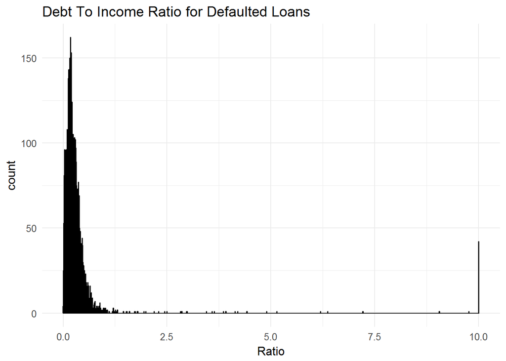

### Description One

the plot above show the distribution of borrower DebtToIncomeRatio for Defaulted loans. the half of borrowers keep rating less than .22 ratio. the interesting thing is the 42 borrowers that have 10 ratio and don’t pay their loans. They may be a good training data for a model that detect fraud in prosper site.

```
##    Min. 1st Qu.  Median    Mean 3rd Qu.    Max.    NA's
##  0.0000  0.1400  0.2200  0.3693  0.3500 10.0100     255
```

```
## [1] 42 85
```

### Plot Two

[interactive chart not shown]

### Description Two

This map show us the lender yield if you invested in a loan based on borrower state. we can see that Alabama and Other states like: Nevada, Idaho, North Dakota, South Dakota, Missouri ,Arkansas, Mississippi, Tennessee, Kentucky are tend to high return between 0.19 and 0.202 and they are the best choice to invest in. the Iowa is the lowest state with mean yield equal to 0.153122. There are the chart of states’ means:

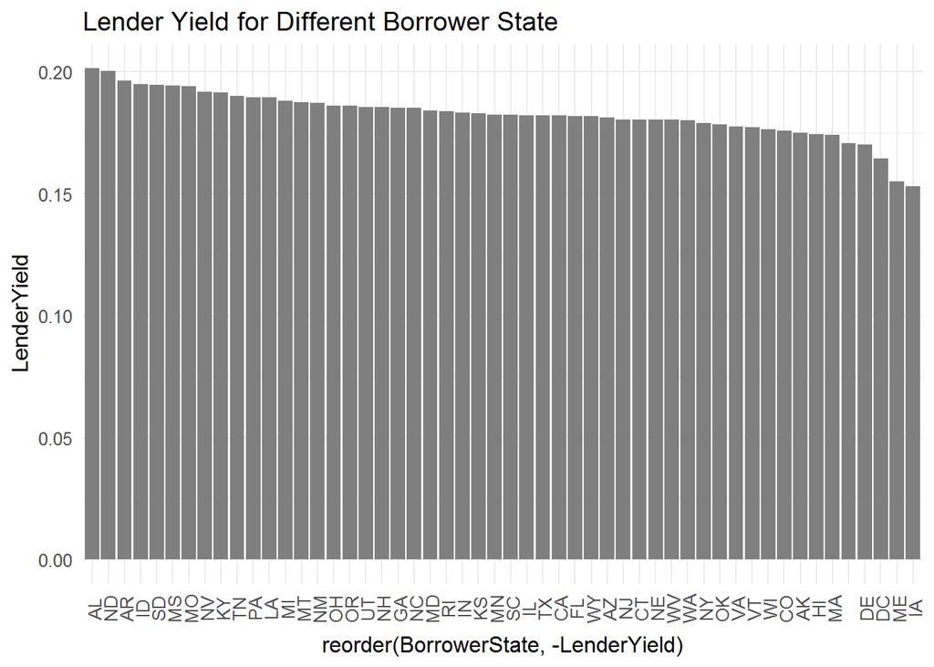

### Plot Three

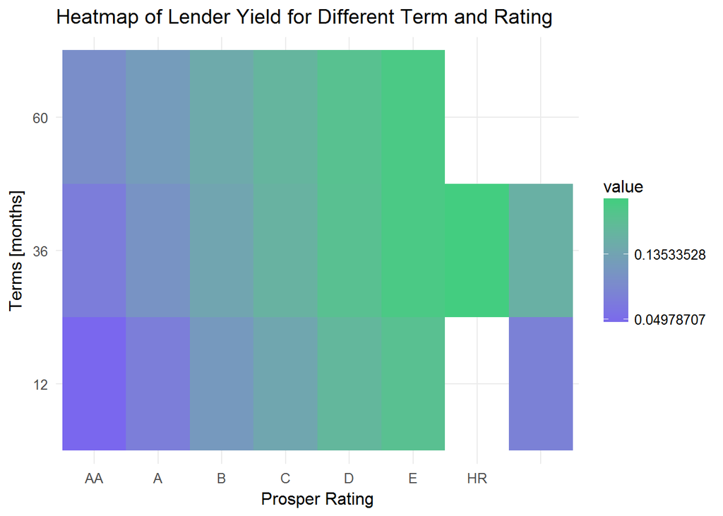

### Description Three

The Heatmap give us important information about lender yield for different term and differnt Prosper alphabetic rating. we can see that lender yield are correlated nigatively with prosper rating the lowest rating tend to high return an the opposite is true. Also term is correlated to them where 36 term tend to high yield about (0.183) than 60 and 12 term(0.182 and 0.140). ** AA A B C D E HR  
0.0691108 0.1029334 0.1444487 0.1844266 0.2364142 0.2833354 0.3073178 0.1730263**

# Reflection

Prosper data contain 81 variable and I explore about 15 variables. I began with the distribution of each variable. After that, I try to find intrested relation between those variable. I try to answer two qustions : which loan give me high yield as an investor? and what is the characteristics of borrower have past due or defaulted loans?.

for first question we can say that invested in loan with 36 term, borrower from albama, have 5 of prosper risk score or E rate. I cant find a good anser for second question but it may be because on variable that I used. I take a lot of time to choose variable from 81 one. and ploting problems like na values and transformation process is one of the difficulties.

For future work, I want to explore more variables like borrower rate. I want to make prediction models like Naive bayes that predict the lender yield.

# Reference

1. Prosper official site: https://www.prosper.com/
2. rMaps: http://stanford.edu/~ggong/rmap/#install-rmap
3. https://en.wikipedia.org/wiki/List_of_U.S._states_by_Gross_State_Product_(GSP)
4. http://feliperego.github.io/blog/2015/10/23/Interpreting-Model-Output-In-R